# Práctica Act 1.5 - Normal Multivariada

Rey Iván De La Fuente Chávez

# Instrucciones

Resuelve esta práctica usando principalmente tu formulario `FormularioMultivariado.Rmd` como apoyo.

- No consultes la Actividad 1.5 original mientras la resuelves.
- Escribe el código necesario debajo de cada inciso.
- Interpreta brevemente los resultados cuando se solicite.
- Cuando termines, haz Knit a HTML y sube el `.Rmd` y el `.html` al repositorio.

**Valor total: 100 puntos.**

# Problema 1 - Probabilidad en una normal bivariada (15 puntos)

Sea

$$X\sim N_2\left(
\begin{pmatrix}
1\\
3
\end{pmatrix},
\begin{pmatrix}
2 & 0.6\\
0.6 & 1.5
\end{pmatrix}
\right).$$

## a) Definir $\mu$, $\Sigma$ y el punto $x=(2,2.5)$ en R (5 puntos)

```r
# Escribe tu código aquí
mu <- c(1, 3)
Sigma <- matrix(c(2, 0.6,
                  0.6, 1.5),
                nrow = 2, byrow = TRUE)
x <- c(2, 2.5)
```

## b) Calcular $P(X_1\le 2, X_2\le 2.5)$ usando `pmnorm()` (10 puntos)

```r
# Escribe tu código aquí
mnormt::pmnorm(x, mean = mu, varcov = Sigma)
```

```
## [1] 0.2973688
```

# Problema 2 - Densidad y contornos (15 puntos)

Usa la misma distribución del Problema 1.

## a) Construir una gráfica tridimensional de la densidad (8 puntos)

Usa un rango aproximado de cuatro desviaciones estándar alrededor de cada media.

```r
# Escribe tu código aquí
sd1 <- sqrt(Sigma[1,1])
sd2 <- sqrt(Sigma[2,2])

x1 <- seq(mu[1] - 4*sd1, mu[1] + 4*sd1, length.out = 100)
x2 <- seq(mu[2] - 4*sd2, mu[2] + 4*sd2, length.out = 100)

f <- function(x1, x2) {
  mnormt::dmnorm(
    cbind(x1, x2),
    mean = mu,
    varcov = Sigma
  )
}

z <- outer(x1, x2, f)

plotly::plot_ly(
  x = x1,
  y = x2,
  z = t(z)
) |>
  plotly::add_surface() |>
  plotly::layout(
    scene = list(
      xaxis = list(title = "X1"),
      yaxis = list(title = "X2"),
      zaxis = list(title = "Densidad")
    )
  )
```

[interactive chart not shown]

## b) Construir el gráfico de contornos (5 puntos)

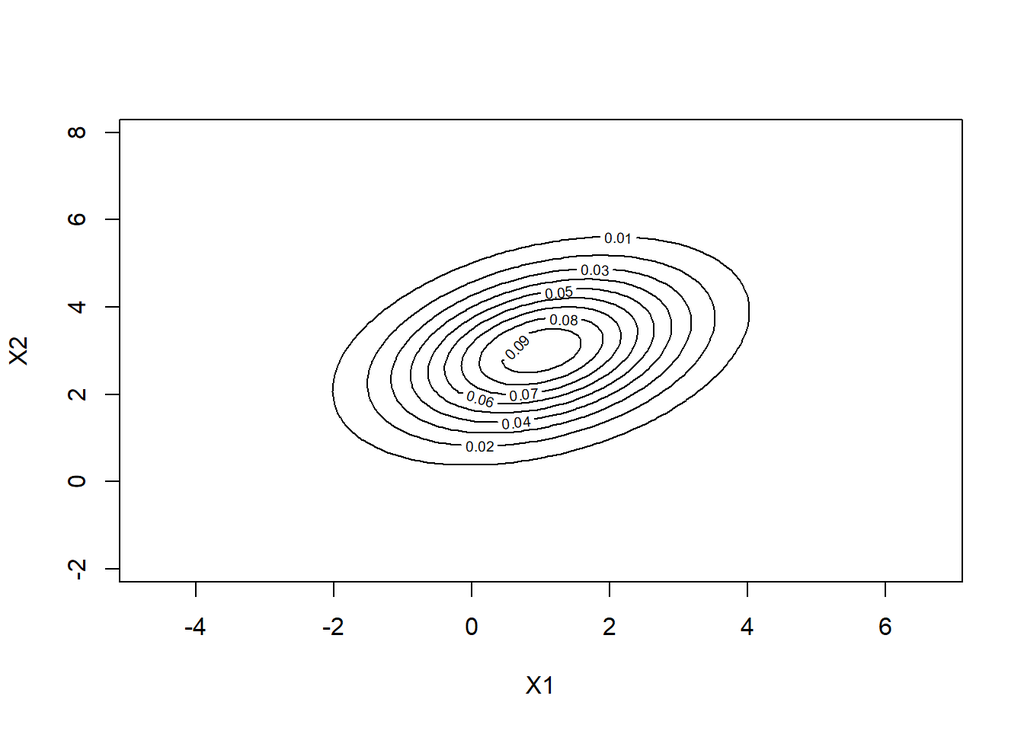

```r
# Escribe tu código aquí
contour(x1, x2, z,
        xlab = "X1",
        ylab = "X2")
```

## c) Interpretación breve (2 puntos)

# Problema 3 - Transformación lineal (25 puntos)

Sea

$$X\sim N_2\left(
\begin{pmatrix}
2\\
-1
\end{pmatrix},
\begin{pmatrix}
4 & 1\\
1 & 2
\end{pmatrix}
\right)$$

y define

$$Y=AX+d,$$

con

$$A=
\begin{pmatrix}
1 & 2\\
-1 & 3
\end{pmatrix},
\qquad
d=
\begin{pmatrix}
4\\
2
\end{pmatrix}.$$

## a) Crear $A$, $d$, $\mu_X$ y $\Sigma_X$ en R (5 puntos)

```r
# Escribe tu código aquí
A <- matrix(c(1, 2,
              -1, 3),
            nrow = 2, byrow = TRUE)

d <- matrix(c(4,
              2),
            nrow = 2, byrow = TRUE)

X <- matrix(c(4, 1,
              1, 2),
           nrow = 2, byrow = TRUE)
mu_x <- c(2, -1)

n <- nrow(X)
unos <- matrix(1, nrow = n, ncol = 1)

Sigma_x <- t(X - unos %*% mu) %*% (X - unos %*% mu) / n
```

## b) Calcular $\mu_Y$ usando $A\mu_X+d$ (8 puntos)

```r
# Escribe tu código aquí
mu_y <- A %*% mu_x + d
mu_y
```

```
##      [,1]
## [1,]    4
## [2,]   -3
```

## c) Calcular $\Sigma_Y$ usando $A\Sigma_XA^T$ (8 puntos)

```r
# Escribe tu código aquí
Sigma_y <- A %*% Sigma_x %*% t(A)
Sigma_y
```

```
##      [,1] [,2]
## [1,]  2.5  7.5
## [2,]  7.5 45.0
```

## d) Escribir la distribución de $Y$ (4 puntos)

Escribe tu respuesta aquí en notación $N_2(\mu_Y,\Sigma_Y)$:

$$Y\sim N_2\left(
\begin{pmatrix}
4\\
-3
\end{pmatrix},
\begin{pmatrix}
2.5 & 7.5\\
7.5 & 45
\end{pmatrix}
\right)$$

# Problema 4 - Combinación lineal (15 puntos)

Usando la distribución de $Y$ obtenida en el Problema 3, define

$$Z=2Y_1-3Y_2+5.$$

## a) Definir el vector de coeficientes y la constante (3 puntos)

```r
# Escribe tu código aquí
a <- matrix(c(2, -3), nrow = 1)
c = 5
```

## b) Calcular $\mu_Z$ (5 puntos)

```r
# Escribe tu código aquí
mu_z <- a %*% mu_y + c
```

## c) Calcular $Var(Z)$ (5 puntos)

```r
# Escribe tu código aquí
var_z <- a %*% Sigma_y %*% t(a)
```

## d) Escribir la distribución de $Z$ (2 puntos)

Escribe tu respuesta aquí:

$$Z\sim N_2\left(
22,
325
\right)$$

# Problema 5 - Evaluación de normalidad multivariada (30 puntos)

Usa los siguientes datos:

```r
M <- data.frame(
  X1 = c(2.1, 2.4, 1.9, 2.8, 3.0, 2.6, 2.3, 3.1, 2.7, 2.5, 4.6, 2.2),
  X2 = c(5.0, 5.5, 4.8, 6.0, 6.3, 5.8, 5.2, 6.4, 5.9, 5.6, 8.7, 5.1)
)

M
```

```
##     X1  X2
## 1  2.1 5.0
## 2  2.4 5.5
## 3  1.9 4.8
## 4  2.8 6.0
## 5  3.0 6.3
## 6  2.6 5.8
## 7  2.3 5.2
## 8  3.1 6.4
## 9  2.7 5.9
## 10 2.5 5.6
## 11 4.6 8.7
## 12 2.2 5.1
```

```r
# Escribe tu código aquí
variables <- c("X1", "X2")
X <- as.matrix(M[, variables])
n <- nrow(X)

unos <- matrix(1, nrow = n, ncol = 1)
mu <- (t(unos) %*% X) / n
```

## b) Calcular las distancias de Mahalanobis y construir el QQ-Plot contra cuantiles Chi-cuadrada (10 puntos)

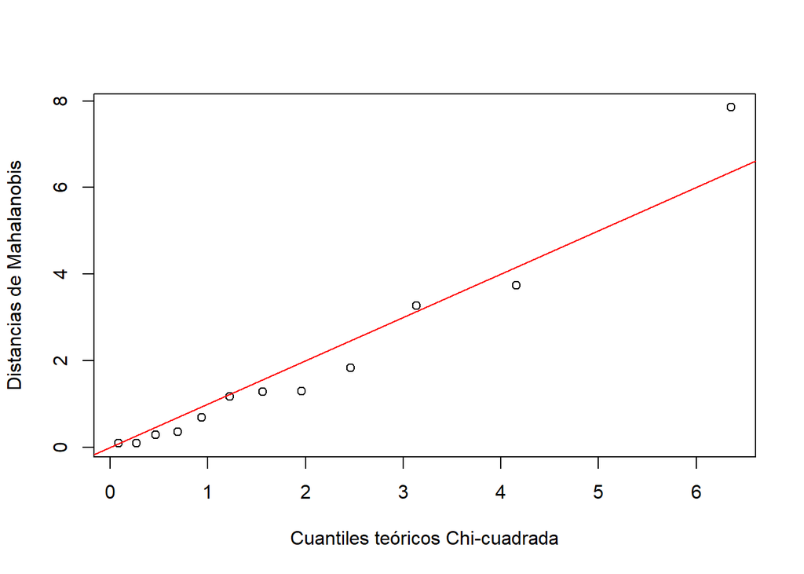

```r
# Escribe tu código aquí
p <- ncol(M)
media <- colMeans(M)
S <- cov(M)
d2M <- mahalanobis(M, media, S)
teoricos <- qchisq(((1:nrow(M))-0.5)/nrow(M), df=p)
plot(teoricos, sort(d2M),
     xlab="Cuantiles teóricos Chi-cuadrada",
     ylab="Distancias de Mahalanobis")
abline(a=0, b=1, col="red")
```

## c) Aplicar la prueba de Mardia (7 puntos)

```r
# Escribe tu código aquí
resultado_mardia <- MVN::mvn(data = M, mvn_test = "mardia")
resultado_mardia
```

```
## $multivariate_normality
##              Test Statistic p.value     Method          MVN
## 1 Mardia Skewness    12.014   0.017 asymptotic ✗ Not normal
## 2 Mardia Kurtosis     0.620   0.535 asymptotic     ✓ Normal
##
## $univariate_normality
##               Test Variable Statistic p.value    Normality
## 1 Anderson-Darling       X1     0.743   0.038 ✗ Not normal
## 2 Anderson-Darling       X2     0.814   0.025 ✗ Not normal
##
## $descriptives
##   Variable  n  Mean Std.Dev Median Min Max  25th  75th  Skew Kurtosis
## 1       X1 12 2.683   0.702   2.55 1.9 4.6 2.275 2.850 1.723    5.772
## 2       X2 12 5.858   1.029   5.70 4.8 8.7 5.175 6.075 1.794    5.984
##
## $data
##     X1  X2
## 1  2.1 5.0
## 2  2.4 5.5
## 3  1.9 4.8
## 4  2.8 6.0
## 5  3.0 6.3
## 6  2.6 5.8
## 7  2.3 5.2
## 8  3.1 6.4
## 9  2.7 5.9
## 10 2.5 5.6
## 11 4.6 8.7
## 12 2.2 5.1
##
## $subset
## NULL
##
## $outlierMethod
## [1] "none"
##
## attr(,"class")
## [1] "mvn"
```

## d) Aplicar Shapiro-Wilk por separado a X1 y X2 (4 puntos)

```r
# Escribe tu código aquí
shapiro.test(M[,1])
```

```
##
##  Shapiro-Wilk normality test
##
## data:  M[, 1]
## W = 0.82074, p-value = 0.01628
```

```r
shapiro.test(M[,2])
```

```
##
##  Shapiro-Wilk normality test
##
## data:  M[, 2]
## W = 0.79969, p-value = 0.009294
```

## e) Interpretación (4 puntos)

Con $\alpha=0.05$, responde brevemente:

- ¿Qué concluye Mardia sobre la normalidad multivariada? Mardía concluye que el sesgo no corresponde a una distribución normal multivariada con un p valor de 0.017, sin embargo concluye que la kurtosis si corresponde a una normal multivariada con un p value de 0.53
- ¿Qué concluye Shapiro-Wilk para cada variable? Saphiro wilk concluye que ninguna de las dos variables se distribuye de manera normal ya que ambas tienen un pvalue muy pequeño
- ¿Coinciden necesariamente la normalidad univariada y la multivariada? No coinciden por lo que la decisión final es que la distribución no es normal multivariada

Escribe tu respuesta aquí:

# Entrega

1. Haz Knit a HTML.
2. Guarda el `.Rmd` y el `.html`.
3. Súbelos al repositorio.
4. Avísame para revisar procedimiento, código, resultados e interpretación sobre 100 puntos.